# Lecture Week 02: Intro

# 1 Overview

- Introduce R, R Studio
- Basic programming
- Working with objects in R
- Functions
- `RxP.csv` data
- Data exploration, visualization, and manipulation

# 2 Setup

### 2.0.1 Libraries

```r
library(tidyverse)
```

### 2.0.2 Data

- `RxP.csv` data
  - available [here](https://global.oup.com/booksites/fdscontent/booksites/uk/booksites/content/9780198869979/RxP.csv)
- Download the data and put it into your `data/` folder.

```r
rxp <- read.csv("data/RxP.csv",
                stringsAsFactors = TRUE)
```

# 3 Lecture Outline

- R is the engine, R Studio is the car
  - Always open R Studio icon
  - Check that you are in your ENVS475 project
    - Top right of R Studio
- Basic expressions
  - R is a calculator

```r
2+2
```

```
[1] 4
```

```r
3 / 2
```

```
[1] 1.5
```

- In the notes, Code blocks look like this:

```r
2 + 2
```

- and Output looks like this

```
[1] 4
```

### 3.0.1 Commenting your code

- Use `#` at the front of a line of code to write notes to your self
- The `#` is used to create a “comment”
- R sees the `#` and ignores everything that comes after it

```r
# how many times does 3 go into 100?
100/3
```

```
[1] 33.33333
```

- Use comments judiciously to take notes and remind yourself what you’re doing
  - Especially while you’re learning
  - Later, try and only leave yourself notes to explain *WHY* you’re doing things, not *WHAT* you’re doing.

## 3.1 Objects

- We can store objects in R to use them later

```r
x <- 3
```

- the `<-` is called the assign operator
  - shortcut: Windows = `ctrl` + `-`
  - Mac = `option` + `-`
- Check environment
  - `x` now has the value of 3
- Can use `x` in calculations

```r
x / 3
```

```
[1] 1
```

```r
x + 3
```

```
[1] 6
```

- The value of x does not change unless we re-assign it

```r
x
```

```
[1] 3
```

```r
x <- x + 3
x
```

```
[1] 6
```

- Note than when we assign a value, it does *not* show us the output in the console
- Need to type `x` again to see what the new value is

## 3.2 Data modes

- R has different classes, or modes that data can be stored in
- `x` above was a numeric mode

```r
mode(x)
```

```
[1] "numeric"
```

- Other types include:
  - `character`: text
    - Note that numbers can be stored as text OR numeric
  - `factor`: a special type of `character` mode which can have `levels`
    - `characters` will automatically be sorted by alphabetical order
    - with a `factor`, You can set the levels to be in any order you want
  - `logical`: either `TRUE` or `FALSE`
  - `numeric`
    - Note that `numeric` classes can be stored as an `integer` (whole numbers) or as a `double` (includes decimal places)
    - R generally automatically switches as appropriate
    - Don’t generally have to worry about it, but you should be aware of it
- Examples of modes

```r
y <- "hello"
z <- TRUE
factor_example <- factor("goodbye")
y
```

```
[1] "hello"
```

```r
z
```

```
[1] TRUE
```

```r
factor_example
```

```
[1] goodbye
Levels: goodbye
```

- Check with the `mode()` function
  - can also check to see if object is a specific mode
  - i.e., `is.factor()` below
  - Returns `TRUE` or `FALSE`

```r
mode(y)
```

```
[1] "character"
```

```r
mode(z)
```

```
[1] "logical"
```

```r
mode(factor_example)
```

```
[1] "numeric"
```

```r
# note that this is NUMERIC
# this is how the order is stored
is.factor(factor_example)
```

```
[1] TRUE
```

## 3.3 Types of objects

- Objects above had a single value stored in it
  - This is known as a `scalar`
- Other data types and brief definitions
  - `vector`: many items in a single dimension, all items have to be the same class (or “mode” in R-speak)
  - `matrix`: many items in two dimensions (organized in rows and columns), all items have to be the same mode
  - `data.frame`: Many items in two dimensions. All items in a column have to be the same type, but different columns can have different mode
  - `list`: An object with many items, where each item can be of any object type, including another list
- We will be primarily working with `data.frames` and `vectors`
- The results of most of our statistical tests will be stored as `lists`

## 3.4 Getting data into R

- Let’s load the `RxP` data into R
- If you didn’t already, run the following code

```r
rxp <- read.csv("data/RxP.csv",
                stringsAsFactors = TRUE)
```

- This is telling R
  - Make an object called `rxp`
  - Make it by using the function `read.csv()`
  - `read.csv()` does what it sounds like, it reads a csv file
  - Specifically, we’re telling it to
    - Look in the folder called `data/`
    - Look for a file called `RxP.csv` in that folder
  - In addition, we’re telling it to make any columns with `character` data (i.e., “strings”) to be a `Factor`
    - This is necessary for a lot of the statistical functions we will use later
- Now we have a thing called `rxp` and we can work with that object
  - More about the data structure below
  - We will go over this again as needed throughout the semester

## 3.5 Looking at objects

- R is a functional programming language
  - We will generally be calling functions to do things
  - functions always have a name followed by a set or parentheses
  - Functions will do something and display it in the console
  - If we want to save the output, we need to use the `<-` operator
- Let’s look at our `rxp` object
  - `str()` shows us the structure
    - Tells us the object type (`data.frame`)
    - Number of rows (obs.) and columns (variables)
    - `$` is before each column name
    - After the name, it shows us the mode, and then shows the first few values in those columns
    - Mode abbreviations:
      - `int` = integer
      - `chr` = character
      - `Factor` = factor
      - `num` = numeric (i.e., decimal number)
    - Also note that we will use the `$` to select columns based on name from data frames

```r
str(rxp)
```

```
'data.frame':   2502 obs. of  14 variables:
 $ Ind              : int  1 2 3 4 5 6 7 8 9 10 ...
 $ Block            : int  5 5 5 5 5 5 5 2 2 1 ...
 $ Tank             : int  7 4 4 7 10 4 4 5 4 1 ...
 $ Tank.Unique      : int  55 52 52 55 58 52 52 17 16 1 ...
 $ Hatch            : Factor w/ 2 levels "E","L": 1 2 2 1 2 2 2 1 2 2 ...
 $ Pred             : Factor w/ 3 levels "C","L","NL": 3 1 1 3 2 1 1 2 1 3 ...
 $ Res              : Factor w/ 2 levels "Hi","Lo": 1 1 1 1 1 1 1 1 1 1 ...
 $ Age.DPO          : int  35 35 35 35 36 36 36 39 39 39 ...
 $ Age.FromEmergence: int  1 1 1 1 2 2 2 5 5 5 ...
 $ SVL.initial      : num  18 17.7 18.1 16.8 18.7 17.5 17.3 19.6 16.5 17.5 ...
 $ Tail.initial     : num  5.4 1.1 5 6.4 6.3 4.4 1.3 1.5 2 5.1 ...
 $ SVL.final        : num  17 18 17.8 17.1 19.3 17.8 17.9 19.6 17.7 19.5 ...
 $ Mass.final       : num  0.38 0.35 0.41 0.3 0.46 0.3 0.42 0.5 0.33 0.46 ...
 $ Resorb.days      : int  3 3 3 3 3 4 2 2 2 3 ...
```

- `head()` shows us the first few row of the data (but not the column mode)
  - Note that it shows us **all** the columns in the console
  - may need to scroll up to see everything

```r
head(rxp)
```

```
  Ind Block Tank Tank.Unique Hatch Pred Res Age.DPO Age.FromEmergence
1   1     5    7          55     E   NL  Hi      35                 1
2   2     5    4          52     L    C  Hi      35                 1
3   3     5    4          52     L    C  Hi      35                 1
4   4     5    7          55     E   NL  Hi      35                 1
5   5     5   10          58     L    L  Hi      36                 2
6   6     5    4          52     L    C  Hi      36                 2
  SVL.initial Tail.initial SVL.final Mass.final Resorb.days
1        18.0          5.4      17.0       0.38           3
2        17.7          1.1      18.0       0.35           3
3        18.1          5.0      17.8       0.41           3
4        16.8          6.4      17.1       0.30           3
5        18.7          6.3      19.3       0.46           3
6        17.5          4.4      17.8       0.30           4
```

- `names()` shows us the column names
  - This is sometimes better than head, especially when there are many columns

```r
names(rxp)
```

```
 [1] "Ind"               "Block"             "Tank"
 [4] "Tank.Unique"       "Hatch"             "Pred"
 [7] "Res"               "Age.DPO"           "Age.FromEmergence"
[10] "SVL.initial"       "Tail.initial"      "SVL.final"
[13] "Mass.final"        "Resorb.days"
```

- `as_tibble()` is a useful function to know
  - a `tibble` is a special data frame
  - Shows us the dimensions (rows and columns) at the top
  - It only shows the number of columns that easily fit in your window
    - Extra column names are listed below
  - It also shows the mode of each column which can be extremely helpful

```r
as_tibble(rxp)
```

```
# A tibble: 2,502 × 14
     Ind Block  Tank Tank.Unique Hatch Pred  Res   Age.DPO Age.FromEmergence
   <int> <int> <int>       <int> <fct> <fct> <fct>   <int>             <int>
 1     1     5     7          55 E     NL    Hi         35                 1
 2     2     5     4          52 L     C     Hi         35                 1
 3     3     5     4          52 L     C     Hi         35                 1
 4     4     5     7          55 E     NL    Hi         35                 1
 5     5     5    10          58 L     L     Hi         36                 2
 6     6     5     4          52 L     C     Hi         36                 2
 7     7     5     4          52 L     C     Hi         36                 2
 8     8     2     5          17 E     L     Hi         39                 5
 9     9     2     4          16 L     C     Hi         39                 5
10    10     1     1           1 L     NL    Hi         39                 5
# ℹ 2,492 more rows
# ℹ 5 more variables: SVL.initial <dbl>, Tail.initial <dbl>, SVL.final <dbl>,
#   Mass.final <dbl>, Resorb.days <int>
```

- note that `read_csv()` is a modified version of `read.csv()` which automatically reads the file in as a tibble
- We will use both in class
  - I generally prefer `read_csv()`
  - But it does not have an easy way of automatically creating `Factors`
  - Some of our analyses require `Factors` , so `read.csv()` will be used.
- Looking at values in a column
  - Sometimes, particularly with character/factor modes, we want to see all the individual values in a column
- Use `unique()` or `distinct()`
  - `unique()` requires a vector
    - We can extract a single column from a data frame as a vector by using the `$`
  - With `distinct()`, we supply the data frame and then the name(s) of the columns separated by a `,`
    - `distinct()` can show us all the unique combinations of multiple variables

```r
# extract the `Block` column as a vector
unique(rxp$Block)
```

```
[1] 5 2 1 4 3 7 6 8
```

```r
# note that this returns a vector

distinct(rxp, Block)
```

```
  Block
1     5
2     2
3     1
4     4
5     3
6     7
7     6
8     8
```

```r
# this returns a one-column data frame

distinct(rxp, Block, Pred) |>
  arrange(Block)
```

```
   Block Pred
1      1   NL
2      1    L
3      1    C
4      2    L
5      2    C
6      2   NL
7      3    C
8      3   NL
9      3    L
10     4    L
11     4    C
12     5   NL
13     5    C
14     5    L
15     6    C
16     6    L
17     7    L
18     7    C
19     8    L
20     8    C
```

```r
# this shows us that block
# 4, 6, 7, and 8
# only have 2 of the three treatments
```

- By combining the `Block` and `Pred` columns, we can see that not all the blocks have all Predator treatments in them
  - The author states that a disease broke out in some tanks, and the data from those were removed.

## 3.6 Plotting data with `plot()`

### 3.6.1 Plotting one variable

- basic plots using the `plot()` function
- Plot all the values of one column by “extracting” the column
  - the `SVL.initial` column records the snout-vent length of individual froglets

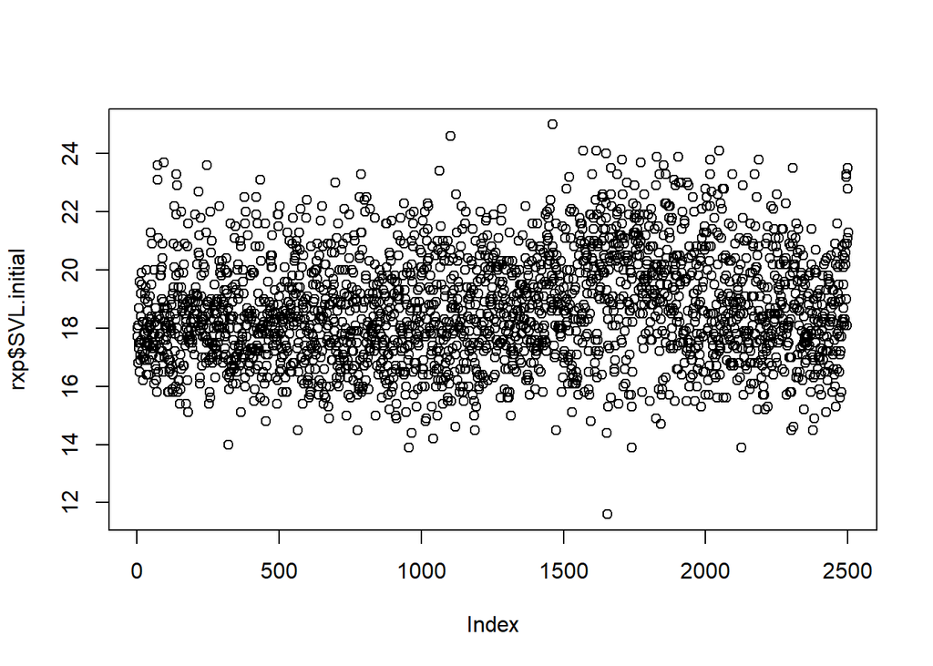

```r
plot(rxp$SVL.initial)
```

- This shows every individual SVL.initial measurement in the data
- The Index is just the number of the row
  - If we re-sorted the data an individual data point would have a different index
- The y-axis shows us the individual value
  - This shows us that the measurements were generally between 14-24 mm
  - **One individual is very small**
  - “most” of the individuals are in the “middle” of the data spread
- Another example of the initial tail length measurement

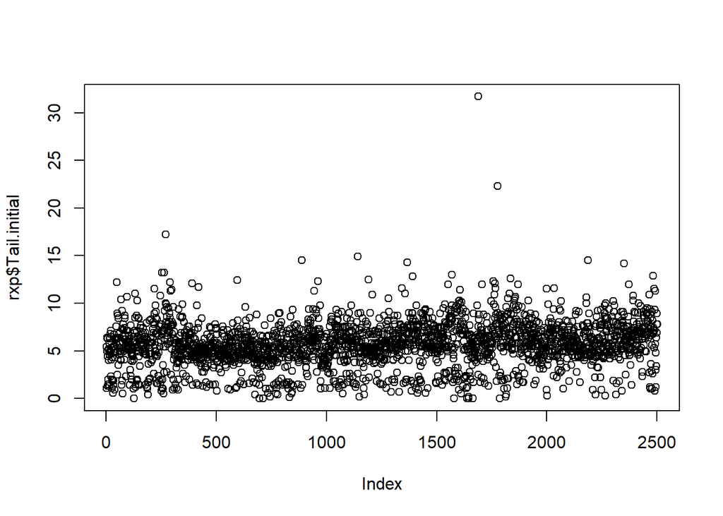

```r
plot(rxp$Tail.initial)
```

- what does this tell us?
  - Any **concerning** observations?
- Plot a factor variable

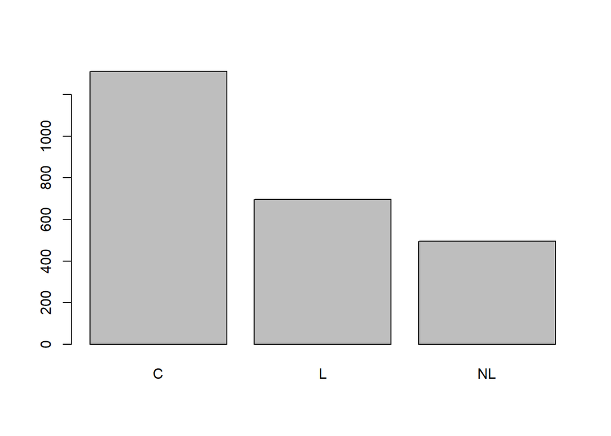

```r
plot(rxp$Pred)
```

### 3.6.2 Plotting two variables

- We can see how variables vary together by plotting them both
- Two options
  - “extract” both variables, separated by a comma (first one = x, second one = y)
  - or separate our y and x variables with a `~` and tell the function which object our data is coming from

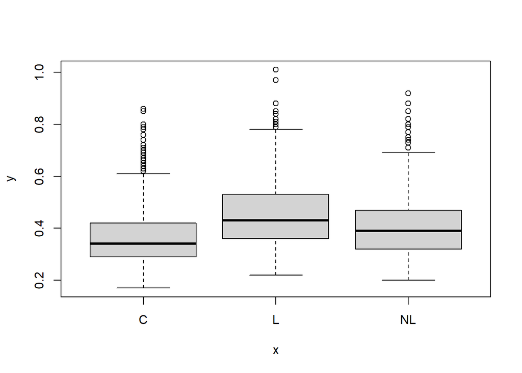

```r
plot(rxp$Pred, rxp$Mass.final)
```

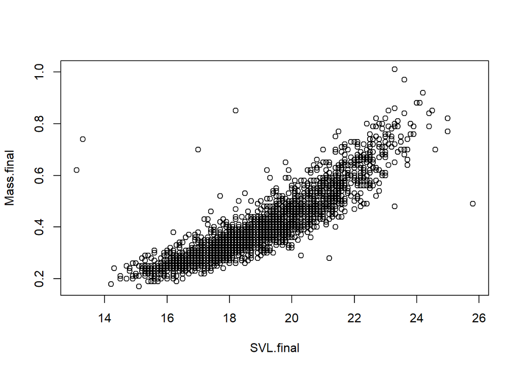

```r
plot(Mass.final ~ SVL.final, data = rxp)
```

- first example had a `factor` and a `numeric` variable
  - R automatically made boxplots to show variation in data by group
- second example had two `numeric` variables
  - R made a scatter plot
- Note that the scatter plot has a “curve” to it
  - This is commonly seen in biological data
  - Indicates a non-linear relationship
  - Common method is to “log-transform” the data
- Two options for log-transformation

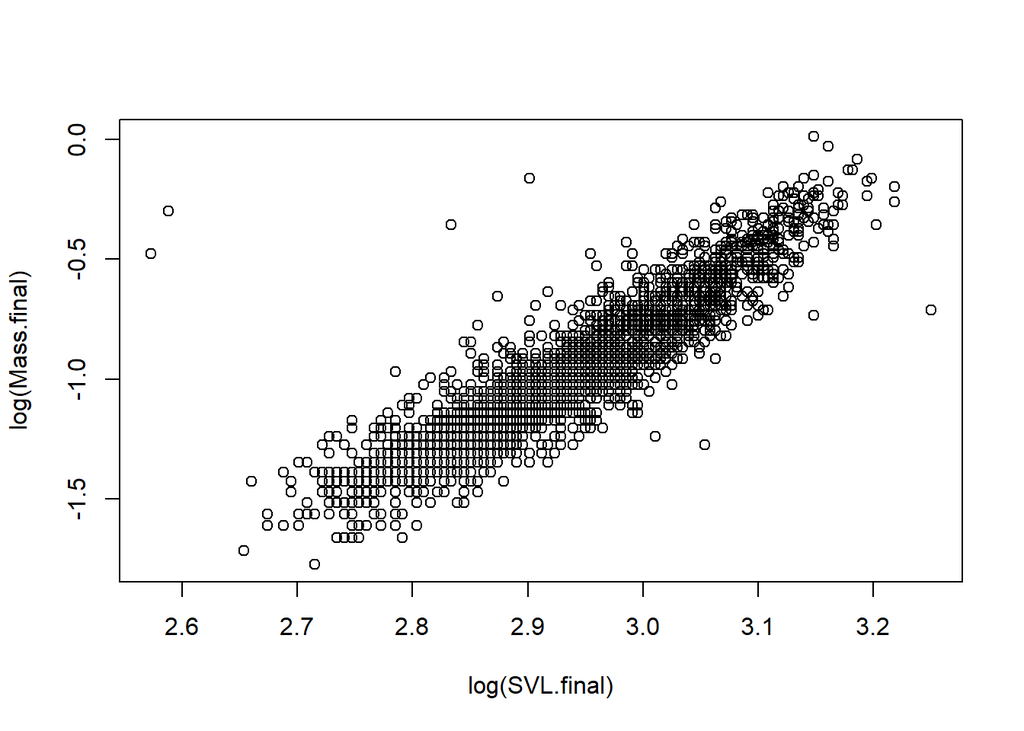

```r
plot(log(Mass.final) ~ log(SVL.final), data = rxp)
```

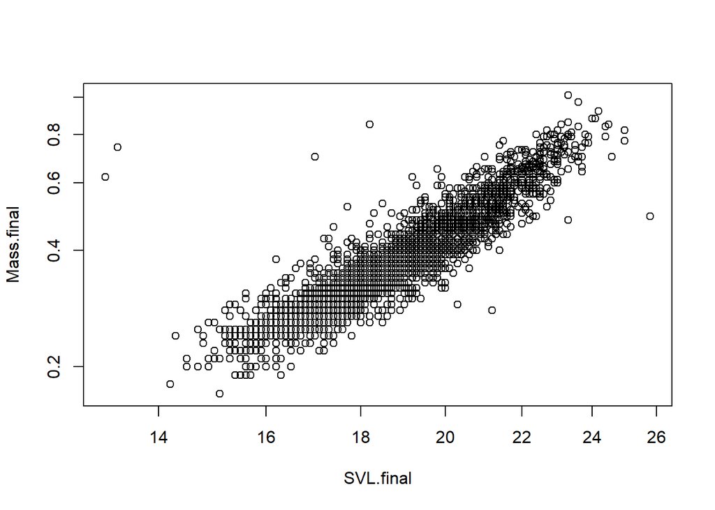

```r
plot(Mass.final ~ SVL.final, data = rxp, log = "xy")
```

- **NOTE** the four “heavy” but “short” individuals
- Jumping ahead - alternatives to log-transformation
  - Analyzing transformed data is ok and has been done for a long time
  - There are a number of problems with it
  - Better alternatives now exist
  - Later in the class, we will explore these

## 3.7 Modifying the data

- The figures above show us that there are 4 individuals with SVL < 19 and mass > 0.6 g
  - In other words, very short, but very heavy individuals
  - Likely impossible to have this combination
  - Could have been an error in data entry or something else
  - We are going to remove these individuals

**Outliers**

- Identifying outliers is difficult and subjective
- You should *NOT* remove data just because it doesn’t fit or looks weird
- I generally avoid removing data as much as possible
  - There are more sophisticated statistical tests which are less sensitive to one or a few extreme values
  - We will go over some of these briefly later in class
- Here, we are going to follow the example in the textbook so that our results match those in the book
- I was not involved in the collection or analysis of this data
- I am trusting the author who was involved and following their lead.
- I’m sure the data are being removed for good reasons
- use the `filter()` command to keep (or discard) certain rows of data
- Keep all rows where the value in `SVL.final` is less than 19

```r
filter(rxp, SVL.final < 19)
```

[output not shown]

- This returns 1300+ rows; That’s a lot of data!
- Let’s also only keep the rows where the value in `Mass.final` is also > 0.6

```r
filter(rxp,
       SVL.final < 19,
       Mass.final > 0.6)
```

```
   Ind Block Tank Tank.Unique Hatch Pred Res Age.DPO Age.FromEmergence
1  734     2    7          19     E   NL  Hi      51                17
2 1024     8    7          91     E    L  Lo      48                14
3 1078     6   11          71     E    C  Lo      54                20
4 1284     1    2           2     E    C  Hi      62                28
  SVL.initial Tail.initial SVL.final Mass.final Resorb.days
1        18.0          0.6      18.2       0.85           1
2        22.2          8.3      13.3       0.74           6
3        16.2          1.5      17.0       0.70           3
4        22.1          9.1      13.1       0.62           6
```

- That’s only 4 individuals, which matches our figure above
- The above code *keeps* these rows and gets rid of everything else
- But we want to *discard* these rows
  - In this case, the best way to do this is by using the values in the `Ind` column
  - Each individual (i.e., row), has a unique `Ind` value
  - So we can get rid of `Ind` 734, 1024, 1078, and 1284
- In addition, there is a long individual with very small mass

```r
filter(rxp,
       SVL.final>24,
       Mass.final<0.6)
```

```
   Ind Block Tank Tank.Unique Hatch Pred Res Age.DPO Age.FromEmergence
1 1127     1    3           3     L    C  Hi      58                24
  SVL.initial Tail.initial SVL.final Mass.final Resorb.days
1        20.3          4.7      25.8       0.49           3
```

- Also remove `Ind` 1127
- Create a `tmp` (temporary) object to store these results
  - Note that `!=` is code for “not equal to”

```r
tmp <- filter(rxp,
              Ind != 734,
              Ind != 1024,
              Ind != 1078,
              Ind != 1127,
              Ind != 1284)
dim(tmp)
```

```
[1] 2497   14
```

```r
dim(rxp)
```

```
[1] 2502   14
```

### 3.7.1 More `filter()` notes

Logical commands to use with filter()

| Symbol | Meaning |
| --- | --- |
| < | is less than |
| <= | is less than or equal to |
| > | is greater than |
| >= | is greater or equal to |
| == | is “already” equal to |
| != | is not equal to |
| & | AND. Note that a `,` separating commands is an implied `&` |
| \| | OR |

```r
filter(rxp,
       SVL.initial == 20.3)
```

```
    Ind Block Tank Tank.Unique Hatch Pred Res Age.DPO Age.FromEmergence
1   290     3    3          27     E   NL  Lo      43                 9
2   300     1    9           9     L    L  Hi      44                10
3   437     3   10          34     L    L  Hi      46                12
4   470     3    3          27     E   NL  Lo      46                12
5   554     3    3          27     E   NL  Lo      47                13
6   632     3   10          34     L    L  Hi      48                14
7   818     1    2           2     E    C  Hi      52                18
8   893     6    5          65     E    L  Lo      50                16
9  1022     5    6          54     E    L  Hi      54                20
10 1080     7    4          76     E    L  Hi      54                20
11 1097     3    8          32     L    L  Lo      56                22
12 1127     1    3           3     L    C  Hi      58                24
13 1176     1    5           5     E   NL  Hi      59                25
14 1177     1    3           3     L    C  Hi      59                25
```

[output cut: 63 more lines]

```r
filter(rxp,
       SVL.initial == 20.3,
       Tail.initial == 8.5)
```

```
  Ind Block Tank Tank.Unique Hatch Pred Res Age.DPO Age.FromEmergence
1 290     3    3          27     E   NL  Lo      43                 9
  SVL.initial Tail.initial SVL.final Mass.final Resorb.days
1        20.3          8.5      20.9       0.45           8
```

## 3.8 AND `&` vs. OR `|`

- Above we were looking for two values in two different columns, so `&` works
- Sometimes we want to find two (or more) values in a single column
- For example, we may want to subset the data to include all the `L` *and* `C` treatments in the `Pred` column
  - Note that our goal is to have `L` *AND* `C`, but to accomplish this we must use the OR `|` operator
  - The value in `Pred` can only be one thing in each row
  - It can never be `L` and `C` at the same time

```r
filter(rxp, Pred == "L") |>
  as_tibble()
```

```
# A tibble: 695 × 14
     Ind Block  Tank Tank.Unique Hatch Pred  Res   Age.DPO Age.FromEmergence
   <int> <int> <int>       <int> <fct> <fct> <fct>   <int>             <int>
 1     5     5    10          58 L     L     Hi         36                 2
 2     8     2     5          17 E     L     Hi         39                 5
 3    14     2     5          17 E     L     Hi         39                 5
 4    16     1    12          12 E     L     Lo         39                 5
 5    18     5     3          51 E     L     Lo         37                 3
 6    19     4     7          43 E     L     Hi         38                 4
 7    21     5     6          54 E     L     Hi         37                 3
 8    26     4     7          43 E     L     Hi         38                 4
 9    27     4     7          43 E     L     Hi         38                 4
10    28     2     5          17 E     L     Hi         39                 5
# ℹ 685 more rows
# ℹ 5 more variables: SVL.initial <dbl>, Tail.initial <dbl>, SVL.final <dbl>,
#   Mass.final <dbl>, Resorb.days <int>
```

```r
# 695 rows

filter(rxp,
       Pred == "L",
       Pred == "C")
```

```
 [1] Ind               Block             Tank              Tank.Unique
 [5] Hatch             Pred              Res               Age.DPO
 [9] Age.FromEmergence SVL.initial       Tail.initial      SVL.final
[13] Mass.final        Resorb.days
<0 rows> (or 0-length row.names)
```

```r
# 0 rows. Values in Pred can never be C AND L at the same time

filter(rxp,
       Pred == "L" |
       Pred == "C") |>
  as_tibble()
```

```
# A tibble: 2,007 × 14
     Ind Block  Tank Tank.Unique Hatch Pred  Res   Age.DPO Age.FromEmergence
   <int> <int> <int>       <int> <fct> <fct> <fct>   <int>             <int>
 1     2     5     4          52 L     C     Hi         35                 1
 2     3     5     4          52 L     C     Hi         35                 1
 3     5     5    10          58 L     L     Hi         36                 2
 4     6     5     4          52 L     C     Hi         36                 2
 5     7     5     4          52 L     C     Hi         36                 2
 6     8     2     5          17 E     L     Hi         39                 5
 7     9     2     4          16 L     C     Hi         39                 5
 8    11     5     4          52 L     C     Hi         37                 3
 9    14     2     5          17 E     L     Hi         39                 5
10    16     1    12          12 E     L     Lo         39                 5
# ℹ 1,997 more rows
# ℹ 5 more variables: SVL.initial <dbl>, Tail.initial <dbl>, SVL.final <dbl>,
#   Mass.final <dbl>, Resorb.days <int>
```

```r
# 2000+ rows
```

### 3.8.1 More outliers

- Couple of more plots to highlight other outliers

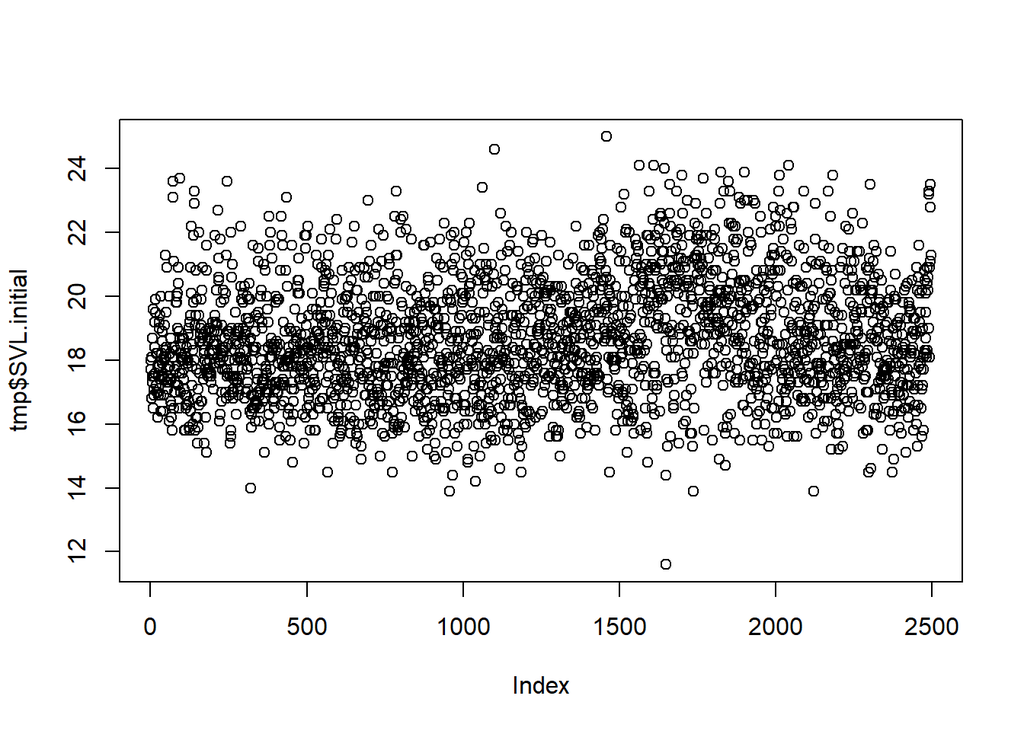

```r
plot(tmp$SVL.initial)
```

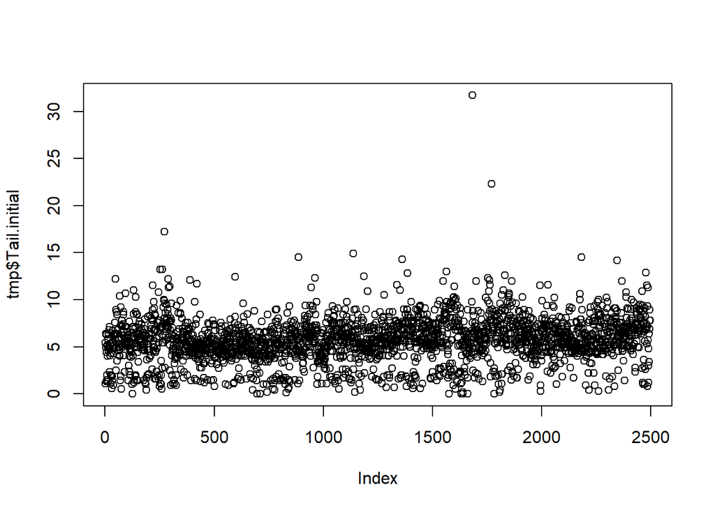

```r
plot(tmp$Tail.initial)
```

- There is one individual with an initial SVL < 12
- There also a couple of individuals with tails > 15 mm
- The author also says these should be removed as they are an “impossibly small” individual or “impossibly long” tails
- We will “overwrite” the `tmp` object to only keep individuals which have SVL > 12 and tails < 15 mm

```r
tmp <- filter(tmp,
              SVL.initial > 12,
              Tail.initial < 15)
dim(tmp)
```

```
[1] 2493   14
```

## 3.9 Save the “cleaned” data

- Now our `tmp` file has all the offending rows removed, and we can save it as a new `rxp_clean` object

```r
rxp_clean <- tmp
```

- We are going to use this data again, so we can also save it as a .csv file
- This will make it easier to load the “clean” data in future classes without having to go through all these steps again

```r
write.csv(rxp_clean,
          "data/rxp_clean.csv")
```

# 4 Summarizing and Manipulating data

## 4.1 `dplyr` “verbs”

- We will be using many helpful functions from the `dplyr` package, which is a part of the `tidyverse` that you already downloaded
- `dplyr` has a number of “verbs” that are incredibly helpful for data exploration, manipulation, and summarization
- We already saw one, `filter()`, which returns rows based on some criteria
  - i.e. `filter(rxp, Pred == "L")`
- The other verbs we will use are
  - `select()` - keeps or discards columns based on name
  - `mutate()` - adds new column(s)
  - `summarize()` - takes many rows and returns one (i.e., a mean)
  - `group_by()` - creates groups in the data to perform operations on

## 4.2 Calculate group means

- We are going to calculate means and estimate variation in our response variables
- We want to do this by “groups”
  - i.e., not usually interested in the average tail length across the full data set
  - Usually more interested in knowing if the mean tail length in the various treatments are the same or different

### 4.2.1 The pipe operator `%>%` or `|>`

- We’re going to take a brief detour
- The pipe operator is a way of stringing together many commands/functions in a row
  - `|>` is the “new” pipe
    - This is a part of the base R system
    - It is the modern way of piping and what you should learn/use
  - `%>%` is the “old” pipe
    - Should still work, and you will see it a lot in tutorials, message boards, etc.
    - You should be aware of it
- Pipes take what’s on the left side and “pipe” it in as the first argument of the function on the right side
- When you see a pipe, you should say “then”
- For example, in the next bit of code, we are going to:
  - Take the `rxp_clean` object THEN
  - We are going to create groups by using the unique combinations of the `Res` and `Pred` columns THEN
  - We are going to calculate the average (mean) value of `SVL.initial` for each group

```r
rp_means <- rxp_clean |>
  group_by(Res, Pred) |>
  summarize(SVL.mean = mean(SVL.initial))
```

[output not shown]

```r
rp_means
```

```
# A tibble: 6 × 3
# Groups:   Res [2]
  Res   Pred  SVL.mean
  <fct> <fct>    <dbl>
1 Hi    C         18.4
2 Hi    L         19.6
3 Hi    NL        19.4
4 Lo    C         17.9
5 Lo    L         19.1
6 Lo    NL        18.4
```

```r
str(rp_means)
```

```
gropd_df [6 × 3] (S3: grouped_df/tbl_df/tbl/data.frame)
 $ Res     : Factor w/ 2 levels "Hi","Lo": 1 1 1 2 2 2
 $ Pred    : Factor w/ 3 levels "C","L","NL": 1 2 3 1 2 3
 $ SVL.mean: num [1:6] 18.4 19.6 19.4 17.9 19.1 ...
 - attr(*, "groups")= tibble [2 × 2] (S3: tbl_df/tbl/data.frame)
  ..$ Res  : Factor w/ 2 levels "Hi","Lo": 1 2
  ..$ .rows: list<int> [1:2]
  .. ..$ : int [1:3] 1 2 3
  .. ..$ : int [1:3] 4 5 6
  .. ..@ ptype: int(0)
  ..- attr(*, ".drop")= logi TRUE
```

```r
rp_means |>
  ungroup()|>
  str()
```

```
tibble [6 × 3] (S3: tbl_df/tbl/data.frame)
 $ Res     : Factor w/ 2 levels "Hi","Lo": 1 1 1 2 2 2
 $ Pred    : Factor w/ 3 levels "C","L","NL": 1 2 3 1 2 3
 $ SVL.mean: num [1:6] 18.4 19.6 19.4 17.9 19.1 ...
```

**Ungroup objects after `summarize()`**

- Note that the output of `rp_means` still has “groups” in it
- You can remove the groups with the `ungroup()` function
- It is recommended you do this to avoid weird behavior in the future
- i.e., if you’re working with a grouped object but don’t realize it, the outputs can be unexpected

### 4.2.2 Reordering factors

- Currently, `Pred` and `Res` are stored as a `Factor`
- Recall that `Factor`’s have an “order” to them
- What is the current order?

```r
levels(rxp_clean$Pred)
```

```
[1] "C"  "L"  "NL"
```

- So Control (“C”) comes before Lethal (“L”) which comes before Non Lethal (“NL”)
- Let’s say we want NL to be before L
- We can accomplish by using the `mutate()` function

```r
rxp_clean <- rxp_clean |>
  mutate(Pred = factor(
    Pred,
    levels = c("C", "NL", "L")))
levels(rxp_clean$Pred)
```

```
[1] "C"  "NL" "L"
```

- This looks a bit confusing so let’s break it down
  - We start by creating a “new” object called `rxp_clean`
  - But we create that by starting with the “old” `rxp_clean` object THEN
  - we create a “new” column called `Pred` using the `mutate()` function
  - We create the “new” `Pred` column by starting with the “old” one
  - We modify the “old” one to be a `Factor` column
  - But we set the order we want inside of the `levels` argument
    - Note that we use the `c()` command inside of the `levels` argument
    - The `c()` function is short for “concatenate” which means “put together”
    - Technically, we are creating a vector inside of the `levels` argument
    - The order that we put things in the `c()` determine the order of the levels

## 4.3 Calculate means and standard errors - `group_by()`, `summarize()` and `mutate()`

- We will now perform a common workflow
- We are going to group our data to calculate *summary* statistics
  - mean, standard deviation (SD), and sample size (n)
- We will then use that information to calculate an *inferential* statistic: Standard Error (SE)

```r
rp_means <- rxp_clean |>
  group_by(Res, Pred) |>
  summarize(SVL_mean = mean(SVL.initial),
            SVL_sd = sd(SVL.initial),
            SVL_n = n()) |>
  mutate(SVL_se = SVL_sd / sqrt(SVL_n)) |>
  ungroup()
```

[output not shown]

```r
rp_means
```

```
# A tibble: 6 × 6
  Res   Pred  SVL_mean SVL_sd SVL_n SVL_se
  <fct> <fct>    <dbl>  <dbl> <int>  <dbl>
1 Hi    C         18.4   1.80   679 0.0692
2 Hi    NL        19.4   1.72   249 0.109
3 Hi    L         19.6   1.62   398 0.0812
4 Lo    C         17.9   1.74   626 0.0697
5 Lo    NL        18.4   1.68   245 0.107
6 Lo    L         19.1   1.74   296 0.101
```

- We are going to use the `rp_means` again later, so let’s save that as a csv

```r
write.csv(rp_means,
          "data/rxp_means.csv")
```

# 5 More plotting with `ggplot2`

- The `plot()` function is useful for making simple graphs
- `ggplot()` is a function which allows the flexibility of creating publication-quality graphics with ease

### 5.0.1 The Grammar of Graphics

- the “gg” in `ggplot` stands for grammar of graphics
- GG has the following setup:
  - `ggplot()` + `geom` + `optional layers`
  - Not the use of the `+` sign to add layers
  - Pipes do not work to add layers to a `ggplot()`
- `ggplot()`
  - Assign the data object using the `data =` argument
  - Assign the aesthetics (i.e., the `x`, `y`) in the `aes()` function
- Add a `geom` which defines the basic plot layout and style
  - `geom_boxplot()` for a boxplot
  - `geom_density()` for a density plot
  - `geom_point()` for a scatter graph
  - `geom_line()` to “connect the dots”
  - Several other options
- Other optional layers to customize the plot
  - `labs()` to add/change plot labels
  - `facet_wrap()` to split the plot into facets
  - many options for changing color, fill, etc.
  - `scales` to change the axis aspects
  - `themes` to set consistent aspects
  - Many other options

### 5.0.2 Plotting one continuous variable

- let’s start making some plots
- We will map one continuous column to either an `x` or `y` aesthetic

#### 5.0.2.1 Histogram

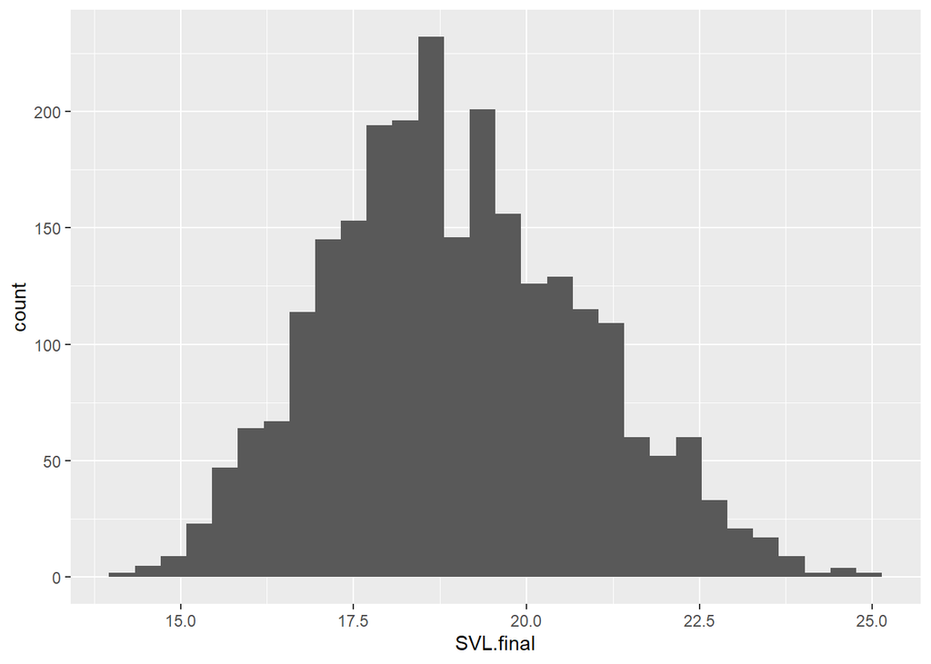

```r
# on the x-axis
ggplot(data = rxp_clean,
       aes(x = SVL.final)) +
  geom_histogram()
```

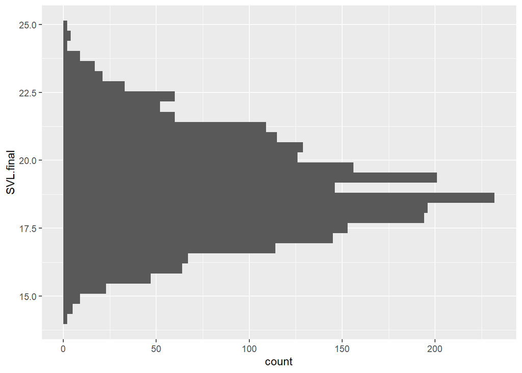

```r
# on the y-axis
ggplot(data = rxp_clean,
       aes(y = SVL.final)) +
  geom_histogram()
```

### 5.0.3 Density plot

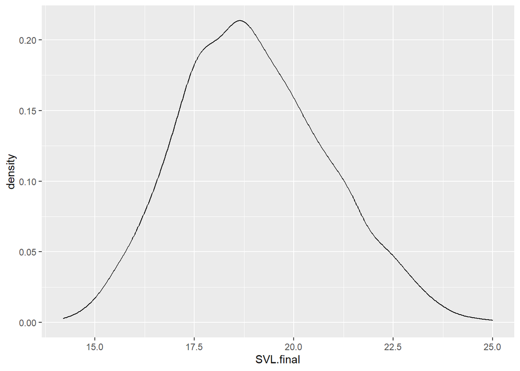

```r
ggplot(rxp_clean,
       aes(x = SVL.final)) +
  geom_density()
```

### 5.0.4 One Continuous variable + one categorical variable

- Map a categorical column (i.e., `Pred`) to a `color` or `fill` aesthetic

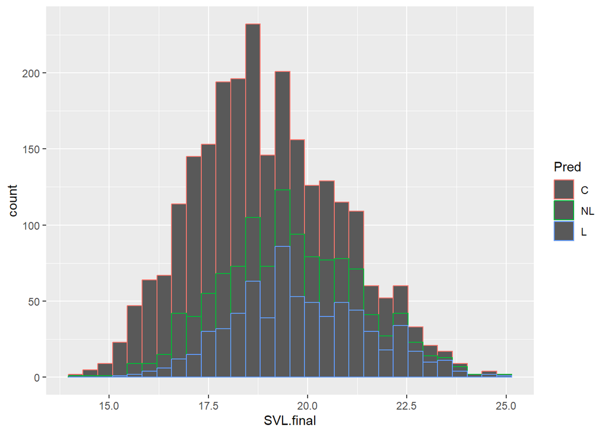

```r
ggplot(rxp_clean,
       aes(x = SVL.final,
           color = Pred)) +
  geom_histogram()
```

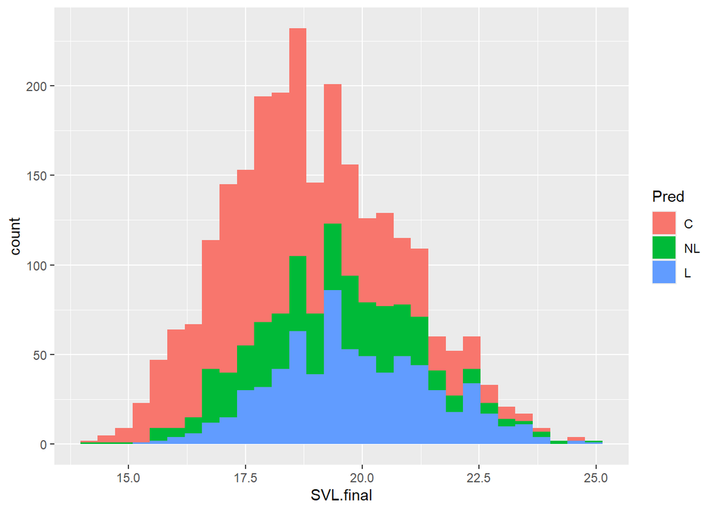

```r
ggplot(rxp_clean,
       aes(x = SVL.final,
           fill = Pred)) +
  geom_histogram()
```

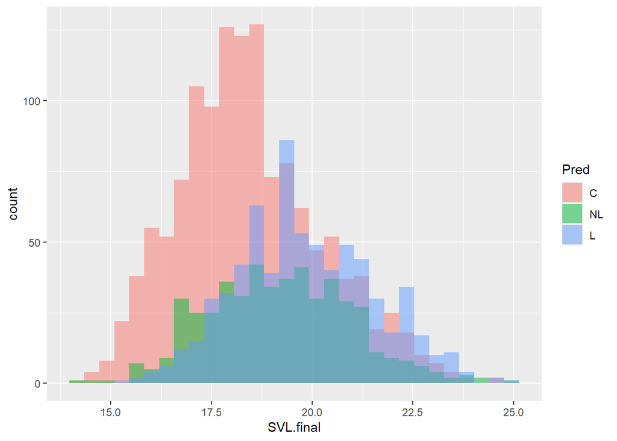

```r
ggplot(rxp_clean,
       aes(x = SVL.final,
           fill = Pred)) +
  geom_histogram(
    position = "identity",
    alpha = 0.5
  )
```

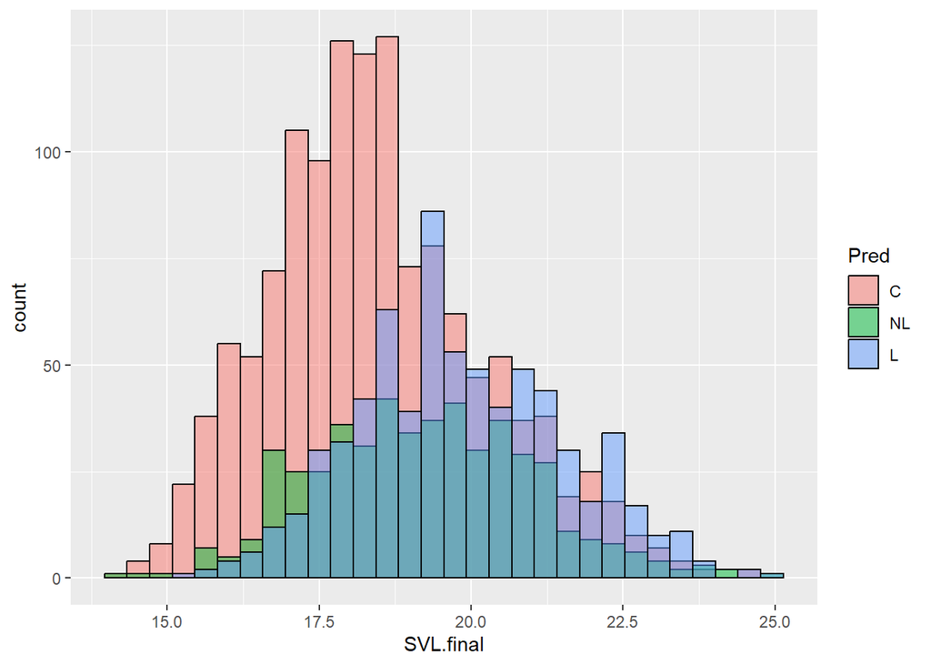

```r
ggplot(rxp_clean,
       aes(x = SVL.final,
           fill = Pred)) +
  geom_histogram(
    position = "identity",
    alpha = 0.5,
    color = "black"
  )
```

- Now all the bars have a black outline

### 5.0.5 One Continuous variable + two categorical variable

- So far, we have looked at how the final length varies across Predator treatments, but there is also the resource treatment
- We can separate these with the `facet_wrap()` function

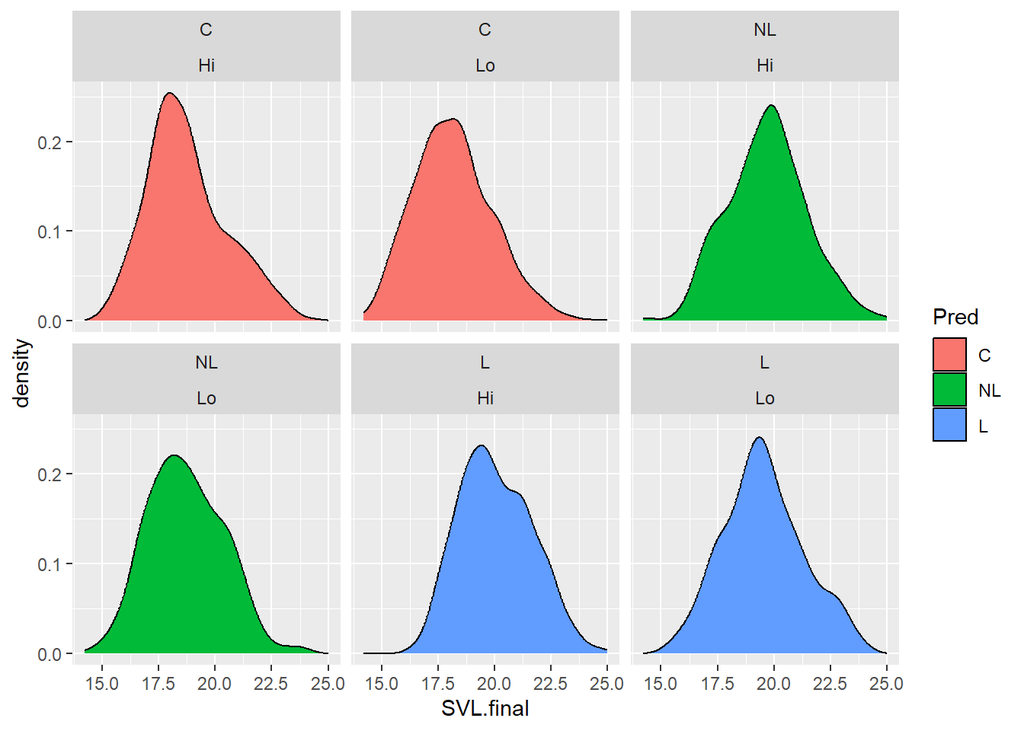

```r
ggplot(rxp_clean,
       aes(x = SVL.final,
           fill = Pred)) +
  geom_density() +
  facet_wrap(Pred~Res)
```

- We can also define `y` as a categorical variable for another version

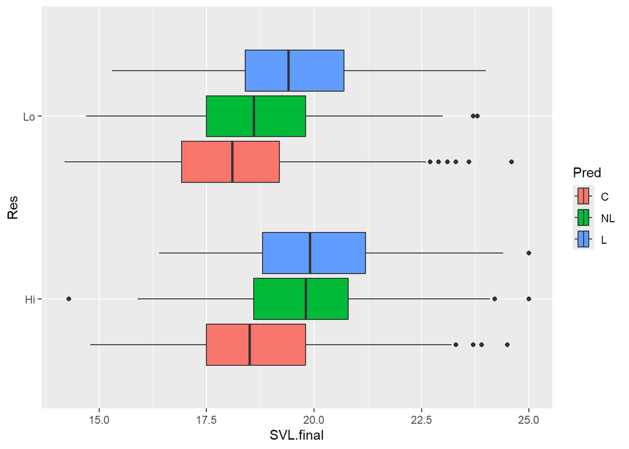

```r
ggplot(rxp_clean,
       aes(x = SVL.final,
           y = Res,
           fill = Pred)) +
  geom_boxplot()
```

### 5.0.6 Plotting summarized data with estimated errors

- Let’s switch gears slightly
- Earlier, we calculated the group means and standard errors
- Let’s plot these using a couple of different methods
- First, recall what the summarized data looks like

```r
rp_means
```

```
# A tibble: 6 × 6
  Res   Pred  SVL_mean SVL_sd SVL_n SVL_se
  <fct> <fct>    <dbl>  <dbl> <int>  <dbl>
1 Hi    C         18.4   1.80   679 0.0692
2 Hi    NL        19.4   1.72   249 0.109
3 Hi    L         19.6   1.62   398 0.0812
4 Lo    C         17.9   1.74   626 0.0697
5 Lo    NL        18.4   1.68   245 0.107
6 Lo    L         19.1   1.74   296 0.101
```

- We have groups of unique combinations of `Res` and `Pred`
- We also have the mean and SE stored in columns
- Let’s plot!

#### 5.0.6.1 Bar plot using `geom_col` for column

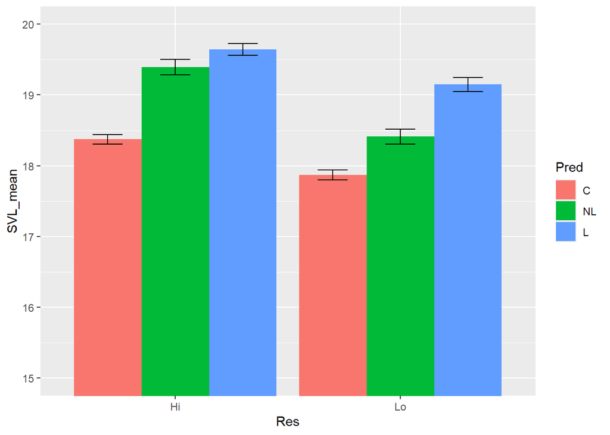

```r
ggplot(rp_means,
       aes(x = Res,
           fill = Pred,
           y = SVL_mean,
           ymin = SVL_mean - SVL_se,
           ymax = SVL_mean + SVL_se)) +
  geom_col(position = "dodge") +
  geom_errorbar(position = position_dodge(0.9),
                width = 0.4) +
  coord_cartesian(ylim = c(15, 20))
```

### 5.0.7 Plotting two continuous variables with and without categories

- Let’s go back to plotting the “raw” data
- Use `geom_point()` when we have two continuous variables in the `x` and `y` aesthetics

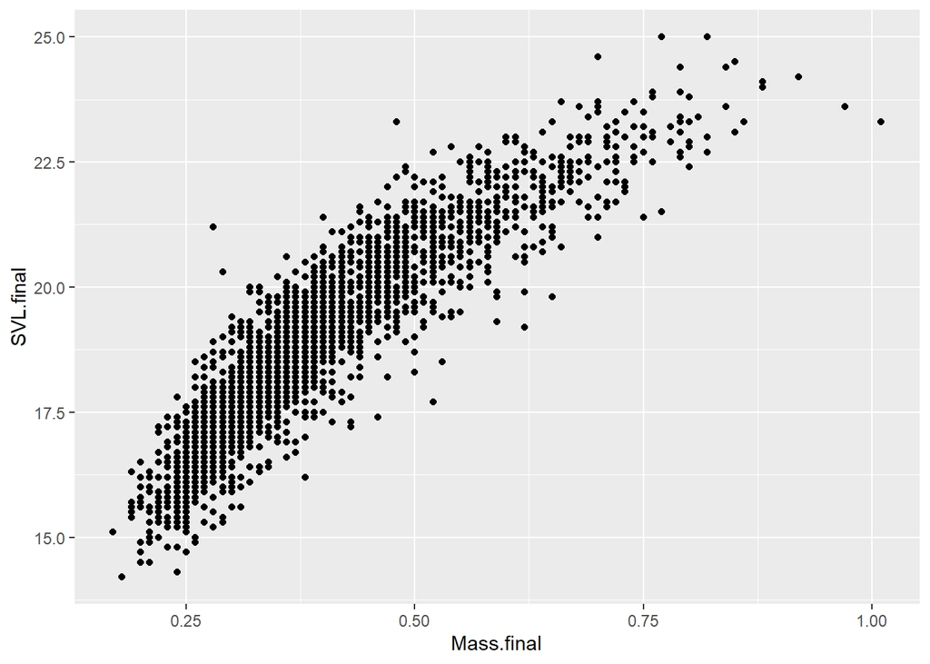

```r
ggplot(rxp_clean,
       aes(x = Mass.final,
           y = SVL.final)) +
  geom_point()
```

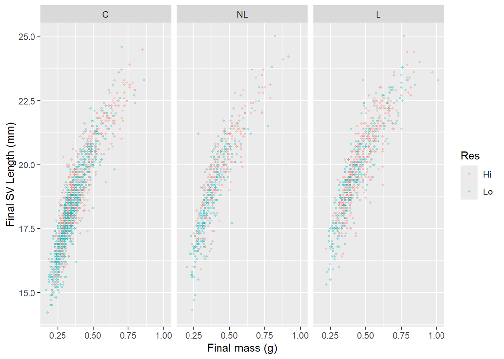

```r
# add color to points, make them small and transparent
# facet by Pred
# improve labels
ggplot(rxp_clean,
       aes(x = Mass.final,
           y = SVL.final,
           color = Res)) +
  geom_point(alpha = 0.3,
             size = 0.75) +
  facet_wrap(.~Pred) +
  labs(y = "Final SV Length (mm)",
       x = "Final mass (g)")
```

### 5.0.8 Themes and inclusive color palettes

- There a number of themes for `ggplot()`
  - `theme_bw()` (my preference)
  - `theme_light()`
  - `theme_dark()`
  - etc., Google “ggplot themes” for more
- There is also the `viridis` color palette which has a number of colorblind-friendly palettes
  - `scale_color_viridis...` and `scale_fill_viridis...` as appropriate
  - the `…` needs to either be:
    - `_d` for discrete data
    - `_c` for continuous dat

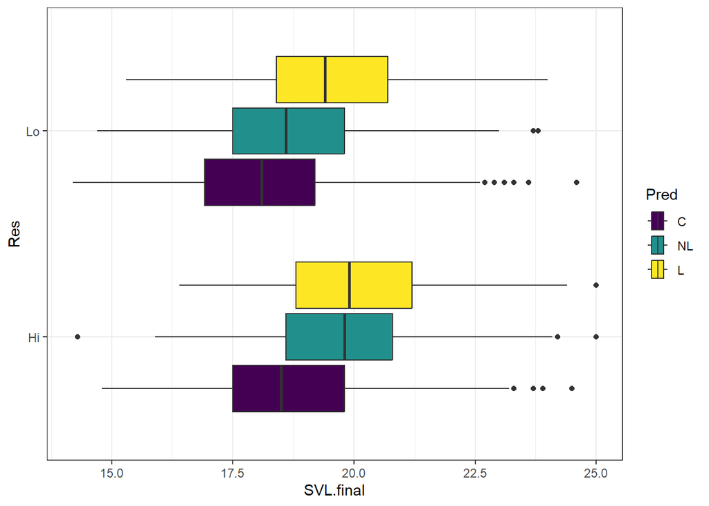

```r
ggplot(rxp_clean,
       aes(x = SVL.final,
           y = Res,
           fill = Pred)) +
  geom_boxplot() +
  theme_bw() +
  scale_fill_viridis_d()
```

- Use `option` = A to H for different palettes

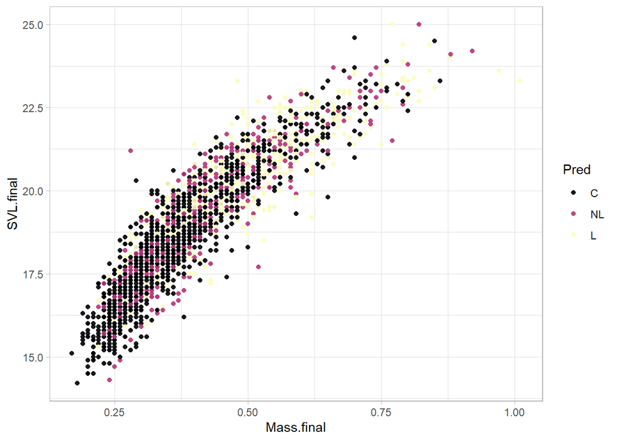

```r
ggplot(rxp_clean,
       aes(x = Mass.final,
           y = SVL.final,
           color = Pred)) +
  geom_point(size = 1.5,
             alpha = 0.9) +
  theme_light() +
  scale_color_viridis_d(option = "A")
```

- Note that it is hard to see the light color in `option = "A"`

**Start and stop for Viridis palettes**

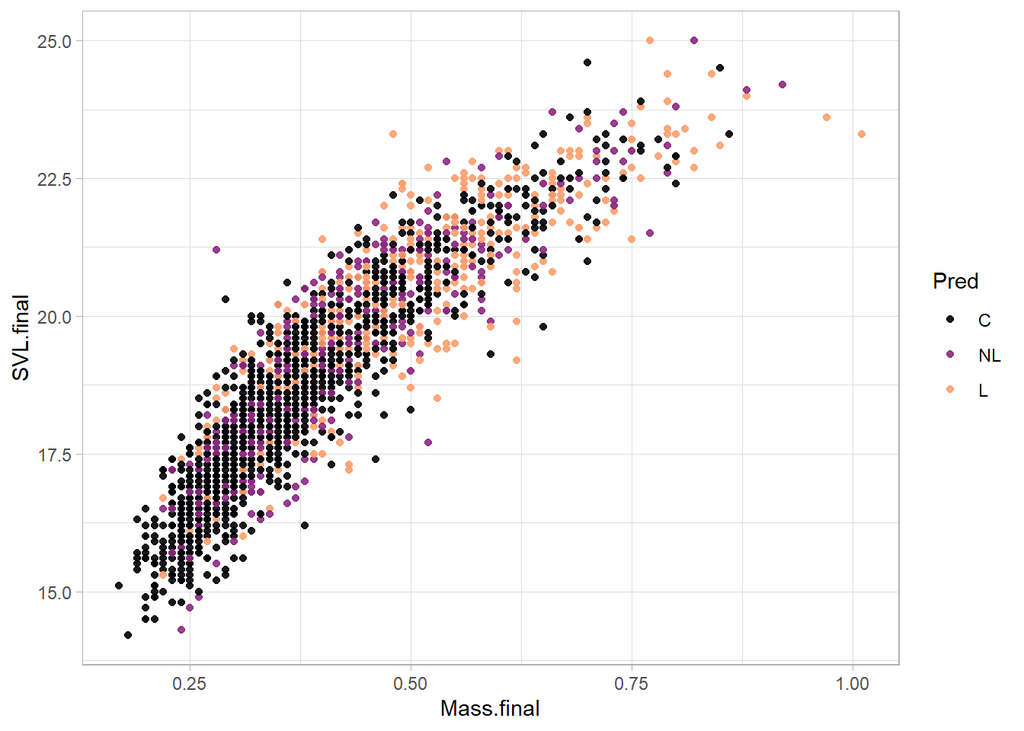

```r
ggplot(rxp_clean,
       aes(x = Mass.final,
           y = SVL.final,
           color = Pred)) +
  geom_point(size = 1.5,
             alpha = 0.9) +
  theme_light() +
  scale_color_viridis_d(option = "A",
                        end = 0.8)
```

- Now the lightest color is a peach/salmon color which is at least a little easier to see.

# 6 Summary

- Always “look” at your data after you import it into R
  - `str()`, `names()`, `dim()`
- What columns do you have? What is the mode of each column?
- For `character` and `Factor` data, what distinct values and/combinations do you have?
  - `distinct(data.frame, col1_name, col2_name, etc.)`
- Plot your data
  - use `plot()` to see the distribution of response variables
  - Use a second categorical/factor/character variable to see how distribution changes across groups
  - Use a second continuous variable to see if there are relationships between the two
- use `dplyr` to subset, modify, and summarize your data.
- Use `ggplot()` to make publication-quality graphics
  - Use of color, facets, transparency and axis labels for communicating data and results.

# 7 Supplemental

## 7.1 Data Info

**Description of the RxP data. Adapted from Box 3.1 in [textbook](https://global.oup.com/academic/product/applied-statistics-with-r-9780197797341?cc=us&lang=en&).**

- The experiment had 96 mesocosm tanks arrayed in an open field in Gamboa, Panama.
  - The Smithsonian runs a field station for tropical research here.
- Investigated how variation in when a frog embryo hatches might affect its development to metamorphosis under various combinations of predators and resources.
- Experimental treatments were as follows:
- Hatching age: Early (four days post-oviposition) or late (six days post-oviposition). Note that oviposition = the act of laying eggs
- Predators: Control (no predator), nonlethal (caged) dragonfly larvae, or lethal (free-swimming) dragonfly larvae.
- Resources: Low (0.75 g) or high (1.5 g) food level, added every five days.
- The mesocosms were spatially arranged in 8 blocks of 12 tanks each.
- The three treatments were “fully crossed” - Each possible combination of treatments was created, resulting in 12 unique combinations of treatments. - The replicates were fully balanced across blocks and randomized within each block.
  - Each block consisted of 1 tank from each of the 12 unique treatment combinations.
- Each tank began with 50 tadpoles
- The experiment ended when all tadpoles reached metamorphosis or had died.
- Metamorphosis is a process that takes time.
- Generally defined as the time from when the froglet’s arms erupt from the body until when the tail is fully resorbed into the body. - The froglet may choose to leave the water early or late during that process.
- Thus, several measurements were taken when the froglets first left the water, and several more when the tail was fully resorbed.
- At metamorphosis, we measured the following response variables:
- Age at hatching, in terms of both time since eggs were oviposited and time since the very first froglet crawled out of the water (defined as day 1).
- Snout-vent length at emergence
- Tail length at emergence.
- Snout-vent length at completion of tail resorption.
- Mass at completion of tail resorption.
- Number of days needed for each metamorph to fully resorb the tail.
- During the course of the experiment, disease broke out in 18 of the mesocosms containing nonlethal predators, and thus those tanks have been removed from the dataset.
- Full citation for the article: Touchon, J. C., McCoy, M. W., Vonesh, J. R., and Warkentin, K. W. 2013. Effects of hatching plasticity carry over through metamorphosis in red-eyed treefrogs. *Ecology*. 94, no. 4: 850–860.